# Manuscript 3 - Stroke Caregiver Burden Bibliometric

Research on Stroke Caregiver Burden, A bibliometric Analysis

Author

Mohd Azmi B Suliman

Published

Wednesday, 07/12/2022

# 1 Front Matter

Title: Research on Stroke Caregiver, A bibliometric Analysis

Authors:

- Mohd Azmi Bin Suliman
- Mohd Khairul Anwar Bin Kamdi
- Tengku Muhammad Hanis
- Kamarul Imran Musa

## 1.1 Abstract

**Introduction**: Stroke is a serious and growing health problem, and since most people with stroke live at home, caring responsibilities generally fall on family members. Caregivers are often inadequately supported by formal health services and have poorer psychological and physical health. Our study aimed to compare the contribution of publications from different countries, institution and authors and present a bibliometric analysis to determine the hotspots and trend in research concerning the health and interventions for family stroke caregivers

Due to the increase in care needs among stroke survivor, the concept of caregiver has emerged. This concept has udergone changes over the years due to new approaches and new research in the area. It is in this context that the concept of informal caregiver emerged.

**Design**: A bibliometric analysis of caregiving literature was undertaken.

`bibliometrix` was used to analyse research published between 2013-2022. A references-based co-citation analysis was used to identify the inttelectual landscape of caregiving research. A keywords-based co-occurence analysis with citation bursts was used to explore research hotspots and frontiers. Lastly, a co-authorship network analysis was used to identify co-operation among authors, countries and institution.

We analysed, via Web of Science (WOS), the scientific output relating to stroke caregivers. Quantitative (number of publications) and citation analyses were performed for output globally

**Aims**: to explore the intellectual landscape of caregiving studies and identify research trends and hotspots in this field.

This study aim to anlyse the evolution of the caregiver concept. Bibliography data was collected from Web of Science Collection and bibliometirc analysis was done.

We aim to analyse the changes in scientific output relating to stroke caregivers

Both stroke caregivers and the care recipient (i.e. the stroke survivors) well-being and rehabilitation process had been the forefront in stroke caregiver related researched.

This bibliometric analysis helps us understand the current state of stroke caregiver research and its recent development

Bibliometric analysis of the studies into stroke caregiver enable us to understanding the intellectual contribution among the author, institutions and countries. This study allowed us to validate our methodology, which could be use to evaluat research policies and to promote international cooperation

**Keywords**: Bibliometric analysis; stroke caregivers burden; research trends

bibliometric analysis; stroke caregiver; research evaluation studies

# 2 Introduction

Increase non-communicable diseases incidence worldwide increase the risk of stroke. With advancement of medical technology, more stroke patients survives their acute stroke episodes. However stroke survivors may develop residual disability. With increase number of stroke incidence, brings with it an increase in the degree of dependence of the stroke survivors, requiring care which brings family changes, which lead to the need to adpat to the new life situation. In this readjustment process, healthcare workers in rehabilitation facilities need to facilitated the management of the transition to the new realityu, implementing interventions aimed not only at the stroke survivors, but also at the family members and caregivers

within the scope of the caregiver’s role, a transition which is commonly seen is the transtion of roles or function. In this type of transition, there is a change in the role played, ofthen within the family, which generates a reformulation of expectation and changes in the defintion of agents as individuals an thier role in the social context. This transition requires and adaptation that include the acquisiton of knowledge, skills and abilitis to deal with the problems that arise at the self-care level and that affect the well-being and, in this sense, the healthcare workers plays a key role in rpomoting the stroke survivors readaptation

As the better positioned professional to help the person in these transition, health care workers assess psychosocial needs and direct their intervetion according to individual needs, empowring the caregiver to perform their role, allowing for greater adherence to the therapeutic regimen of the stroke survivors.

**Note**

1 para (3-4 sentences) on stroke & stroke epidemiology

The health of caregivers can be overlooked and they have been referred to as ‘silent patients’ or ‘secondary patients’. The negative outcomes associated with caregiving include depression and anxiety, and caregivers exhibit high rates of mood disorders. The heavy burden and psychological distress caused by caring for relative with dementia may also contribute to severe physical and psychiatric problems and higher mortality risk. Recognizing this need, interventions have been developed to address the negative effect of caregiving, including education, respite, psychotherapeutic, family support, and multicomponent approaches. In recent decades, the research on this topic has covered a wide spectrum. However, a detailed analysis if the existing research publication landscape has not been undertaken to elucidate the body of published evidence. Such an analysis would be helpful for delineating the global trends in the research fields related to the health of and interventions for stroke caregivers.

the caregiver present themselves as an ally to the health team. Person-centred care is a partnership between the stroke survivors and teir caregivers, whether family, neighbours, or friends, who provide emotional, physical or practical support in response to illness, disability or needs. This type of approach implies that the specific needs, preferences and expectations of the stroke survivors and their caregivers are continuously assessed, respected and considered in care planning, implementation and adaptation of care over time.

Based on the approaches mentioned above, informal caregivers should be seen as an integral part of the health system, due to their high relevance in today’s society, in order to maintain the quality of care and quality of life of both stroke survivors and the caregiver themselves. The care developed should be centred on the person and the caregiver, who is conisdered in several countries as a critical component of high=quality care, respecting their needs, preferences and expectaions when implementing and adapting the care plan for adherence to the therapeutic regime. In this sense, the caregiver is the main focus of attention, which justifies the development of this research.

Stroke survivors often experience considerable distress. Meanwhile, their caregivers may also experience mental and physical problems, such as depression, seleep distrubances and fatigue.

recently, researchers have not only focused on patients, but also on the health of caregivers. Studies indicate that caregivers paly an important role in the rehabiliation process of patients. moreover, many interventions for patient-caregiver dyad have attempted to improve both caregiver’s and patient’s ehalth.

Recently, research on caregiver has increased greatly and many related articles have been published by academic journals. However, researcher on caregivers has increse greatly and many related articles have been publisehd by academic journals. However, researchers have yet analyse systematically the evolution of academic achievements in this field. Thereofre, an innovative method is needed to make sense of the state of resaerhc on stroke caregivers.

**Note**

1-2 para (6-8 sentences) on stroke caregiver

- epidemiology
- need for intervention

Scientometrics is the quantitative study of science, communication in science and science policy. An integral part of scientometric analysis is bibliometric mapping. Bibliometric analysis combines mathematical and statistical mehtods for quantitative analysis. Bibliometric and scientometric analyses have been widely used in various areas to analyse previous research, explore evolution processess, and predict emerging trends in a specific field. In field of nursing, bibliometric and scientometric analyses have been appplied to analyse journal publications and compared differnt journals. Additionally, this method has been adopted to analyse specific topics, such as chronic disease self-management and pain management. However, to our knowledge, no study has used bibliometric analysis to explore the research trends and hotpsot of caregiving studies, specific to stroke caregivers. In this study, we conducted a systematic analysis of past studien on stroke caregivers, using `bibliometrix` package in R.

biomedical research has expanded markedly in recent years, with number of articles indexed in PubMed more than doubling from 414k articles to 1023k articles in 2016. Has the number of publications in stroke caregivers double over the same period? which countries are most active in this research? what kind of research has been performed?

**Note**

optional 1 para on bibliometric analysis - redundant with methodology part

- 10.3145/epi.2020.ene.03

for number of articles in database

- https://doi.org/10.1162/qss_a_00018

The aims of this study were to examine the publication patterns of research on stroke caregiver burden at a global level. we attempted to provide comprehensive insights into the current state of global research, including annual output characteristic, international collaborations, and keywords trends. The results should provide a better understanding of the global trends in the research on the stroke caregiver burden and indicate directions for further research.

In the preparaion of this research, it was found that there are several terms related to the informal caregiver/family caregiver and not all terms are part of DECS and MESH. On the other hand, it become important to ideitfy the researchrs who stand out for the quality and peer recognition of their contribution, as weel as the pattern of publication and their behaviour over time. Thus with this bibliometric analysis of published studies related to the concept of informal caregiver / family caregiver, we intended to answer the following research question: How is the scientific production on the concept of informal caregiver characterized? The general objective was to present the characteristics of the scientific production on the topic, specifically regarding the aspects of authorship, cited work, co-authorship networks and bibliographic coupling.

THe main aim of this study was to identify research trends, journals, and disciplines that were most represented in caregiver studies in journals. An additional aim was to explore the intellectual landscape of studies on caregivers. Furthermore, we aimed to identify which research frontiers could lead to collaborations between countries, authors, and isnstitution.

**Note**

1 para for objectives and study justification

# 3 Methodology

The data were downloaded from public databases and as secondary data, did not require any interactions with human subjects. There were no ethical issues associated with the data, and approval from institutional review boards was not required.

Bibliometrics is defined as the application of statistics and mathematics for the analysis of written publications such as books and journal articles. Bibliometric techniques can be used to perform statistical and quantitative analysis of publications and offer a convenient way to visibly measure researchers efforts in the investigation of a specific field. Such analyses can characterize the development in certain field and have contributed substantially to informing policy making, clinical guidelines and research trends. Impact factors were taken from those published by the WOS in 2018. Cooperation among countries or institution was based on the first authors. Collaboration type was determined by the addresses of the authors, where the term ‘single-country article’ was assigned if the researchers’ addresses were in the same country. The term ‘internationally collaborative article’ was used to designate those articles that were co-authored by researchers from multiple countries.

The data were analysed both quantitatively and qualitatively. We describe the research status of this field based on statistics regarding the number of articles and their distribution across countries and in time and space, subjects, journal, and high-yield institutions and authors. Moreover, the corpus was analysed to generate different scientific landscapes and networks. We analysed the cooperation situation in this field among countries and institutions via cooperation analysis; the intrinsic links among authors via bibliographic coupling; and the reference network and frequently cited literature via co-citation analysis. in the hotspot analysis, we captured high-frequency keywords for the clustering and co-occurrence analyses. The bibliometric analysis in this study was performed and visualized using `bibliometric` package in R and RStudio.

Web of Science was selected as the academic publication source in this study because it is the largest research database.

## 3.1 Type of Research

This is a bibliometric analysis, which essentially consist of a statistical and quantitative technique that allow the measuring of the production and dissemination rate of knowledge, monitoring of the development of the concept under study in the various scientific areas and areas of interest, and analysis of publication patterns. This type of analysis aims to quantify and analyse the processess of written communication through mathematical and statistical analysis to determine the nature and historical evolution of a particular discipline or concept.

This analysis assume significant importance since it deciphers and maps scientific knowledges as well as established nuances, responding to large volumes of data in a consistent manner, building solid bases for scientific contribution according to their respective fields of action. Thus bibliometric analysis can reveal emerging development areas of scientific knowledge in a respective field, contributing to the evolution of scientific knowledge and generating research opportunities.

This methodology has been rapidly growing academic interest among researhcers due to the increased availability of databases and software used.

This analysis was conducted following four steps: (1) Definition of the study objective; (2) Choice of the analysis technique; (3) collection of data for analysis; (4) performance of the bibliometric analysis and exposure of the respective result.

## 3.2 Ethical consideration

As this study was conducted without any huma subjects, an ethical review was not required.

## 3.3 Search Strategry, Study Selection and Data Extraction

A search in Web of Science was then performed with the following search equation: (TI=(stroke) AND TI=(caregiver)), refined by: Document Types: (ARTICLE).

The search was performed on 3rd December 2022 at 09:00 GMT +1. After the search in the Web of Science, bibtex data was download and analysed using `bibliometric` package in R (version 4.2.2) and RStudio (version 2022.07.2) (Aria and Cuccurullo 2017; R Core Team 2022; RStudio Team 2022).

The search and data extraction were validated by two independent researchers.

Literature retrival was conducted using the Web of Science Database, on 3rd Decembeer 2022.

## 3.4 Statistical Analysis of the Data

The bibliometric analysis was carried out simultaneously to the extraction of the bibliometric data and took into consideration its two main techniques: performance analysis, which allows examining the contributions of research to a given field in a descriptive way and which reveals itself as initial phase of bibliomteric studies; and scientific mapping, which examines the relationships between the constituients of research, where analysis relates to the intellectual interaction and structural connections between the constituents of research.

The descriptions of the data based on graphs, figures and tables were produced by the `bibliometix` packages in R and RStudio.

biliometric analysis was carrioud using R and RStudio, and `bibliometrix` packages. The `bibliometrix` packages was used to visualize the distribution of research fields, generate cluster of co-citing reference publication, explore the intellectual landscape of studyies about caregivers by time, analyse co-occuring keywords and burst terms to detect trends and frontiers, and identify leading collaboration among countries, authors and instituition.

Data were extracted from the Web of Sciences

## 3.5 Search Term

To ensure the publications were focus on stroke caregivers, the term use only limit to term “Stroke” and “caregiver” in the title.

## 3.6 Analysis

after search term, bibtex data were download from WOS, and analysed in R and RStudio with `bibliometrix` packages. `bibliometrix` packages allowed analysis of bibliometric indicators relating to authors, institutions, countries and region. It also allow investigator to focus on thematic fields.

We first compared the total global output relating to stroke caregiver. We then lloked at the contribution from major countries to the global output, assessed on the basis of number of articles with authors from each country.

In addition, the impact of the research was evaluated by analysis of the frequency of citations. However, the number of citation depend in part on the year of publication - older articles have had more opportunity to be cited, and the scientific field.

**Note**

update these 2 para

- methodology - what was done in analysis (i.e. the result)

# 4 Results

```r
pacman::p_load(tidyverse, bibliometrix, janitor, stringi, gtsummary, igraph,
               gtsummary, kableExtra, metagear)

bibds1_wos <- convert2df(file = "22-12-07 WOS_TIstcgp1.bib", dbsource = "wos",
                        format = "bibtex")
bibds2_wos <- convert2df(file = "22-12-07 WOS_TIstcgp2.bib", dbsource = "wos",
                        format = "bibtex")
bibds_wos <- bind_rows(bibds1_wos, bibds2_wos)
bibres <- biblioAnalysis(bibds_wos)
bibres_summary <- summary(bibres)

bibres_plot <- plot(bibres, k = 10)
```

```r
# error for plot

bib_lang <- bibds_wos %>%
  group_by(LA) %>%
  summarise(n = n()) %>%
  mutate(percent = n / sum(n) * 100,
         percent = round(percent,1)) %>%
  arrange(desc(n))

bibres_countrylist <- bibres$Countries

bibres_countrytable <- tibble(Rank = seq_along(bibres_countrylist),
                              Country = rownames(bibres_countrylist),
                              Np = as.integer(bibres_countrylist)) %>%
  mutate(Country = fct_reorder(Country, Rank),
         percent = Np / sum(Np) * 100,
         percent = round(percent,1))

bibressum_countrytable <- tibble(Rank = 1:10,
       bibres_summary$TCperCountries) %>%
  rename("Country" = "Country     ") %>%
  mutate(Country = str_trim(Country),
         Country = fct_reorder(Country, Rank),
         `Total Citations` = as.integer(`Total Citations`),
         `Average Article Citations` = as.double(`Average Article Citations`),
         percent = `Total Citations` / sum(`Total Citations`) * 100,
         percent = round(percent,1)) %>%
  inner_join(x = ., y = select(bibres_countrytable, Country, Np),
             by = "Country") %>%
  relocate(percent, .after = `Total Citations`)

bibres_instlist <- bibres$Affiliations

bibres_insttable <- tibble(Rank = seq_along(bibres_instlist),
                           InstitutionAffiliation = rownames(bibres_instlist),
                           Np = as.integer(bibres_instlist)) %>%
  mutate(InstitutionAffiliation = fct_reorder(InstitutionAffiliation, Rank))

bibres_sourcelist <- bibres$Sources

bibres_sourcetable <- tibble(Rank = seq_along(bibres_sourcelist),
                             SourceJournal = rownames(bibres_sourcelist),
                             Np = as.integer(bibres_sourcelist)) %>%
  mutate(SourceJournal = fct_reorder(SourceJournal, Rank))

bibres_sourcetablepercent <- bibres_sourcetable %>%
  count(Np) %>%
  mutate(percent = n / sum(n) * 100,
         percent = round(percent,1))

bib_bradford <- bradford(bibds_wos)

bib_bradfordtable <- bib_bradford$table %>%
  select(Zone, Freq, Rank) %>%
  tibble() %>%
  group_by(Zone) %>%
  summarise(nSO = n(),
            nArt = sum(Freq),
            RankRange = str_c(min(Rank), max(Rank), sep = "-")) %>%
  mutate(percent = nArt / sum(nArt) * 100,
         percent = round(percent,1))

bibds_noaufreq <- bibds_wos %>%
  select(TI, AU, DT) %>%
  tibble() %>%
  mutate(no_auth = stri_count_regex(AU, c(";")) + 1,
         DT = fct_recode(DT,
                         "ARTICLE" = "ARTICLE; PROCEEDINGS PAPER",
                         "ARTICLE" = "ARTICLE; EARLY ACCESS")) %>%
  rename("paper" = "TI", "author" = "AU", "type" = "DT") %>%
  group_by(no_auth, type) %>%
  summarise(freq = n(), .groups = "drop") %>%
  mutate(percent = freq / sum(freq) * 100,
         percent = round(percent,1))

bibres_aulist <- bibres$Authors

bibres_autable <- tibble(Rank = seq_along(bibres_aulist),
                         Author = rownames(bibres_aulist),
                         Np = as.integer(bibres_aulist)) %>%
  mutate(Author = fct_reorder(Author, Rank))

bibres_autablepercent <- bibres_autable %>%
  count(Np) %>%
  mutate(percent = n / sum(n) * 100,
         percent = round(percent,1))
```

## 4.1 General Information

```r
bibres_summary

# bibres_summary$AnnualProduction
```

[output not shown]

<sup>1</sup> manual

[figure not shown]

Figure 1: Flow diagram for the inclusion of publication on the stroke caregiver burden

```r
prismaplot <- plot_PRISMA(
  c("START_PHASE: Studies identified through databse searching (n=1,004)",
    "Publication Year: 2013-2022 (n = 662)",
    "EXCLUDE_PHASE: before 2013 (n = 342)",
    "Publication Type: Articles only (n=411)",
    "EXCLUDE_PHASE: Other Type (n = 251)",
    "Included in the analysis (n=411)"),
  design = "classic", colWidth = 25, excludeDistance = 1
  )
```

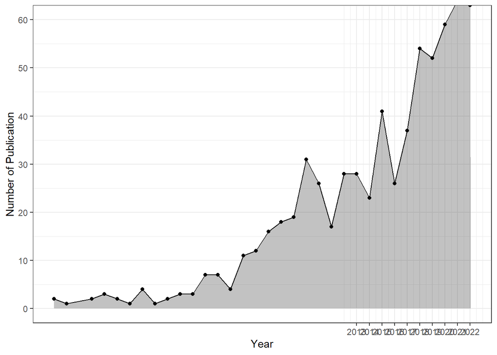

Figure 2: Number of Publications by Year

```r
# bibres_plot$AnnualScientProd
# error plot - refer setup chunk

tibble(Article = rownames(bibds_wos),
       Year = bibds_wos$PY) %>%
  group_by(Year) %>%
  summarise(n = n()) %>%
  ggplot(aes(x = Year, y = n)) +
  geom_area(alpha = .3) +
  geom_point() +
  geom_line() +
  scale_y_continuous(breaks = seq(0,60,10)) +
  scale_x_continuous(breaks = seq(2013,2022,1)) +
  coord_cartesian(ylim = c(0,60)) +
  labs(x = "Year", y = "Number of Publication") +
  theme_bw()
```

## 4.2 Languange

In the field, the articles were published in total nine languages, with majority of the articles published in English language with whopping 96%. The articles were also published in German with seven articles, Portuguese and Spanish with six articles, and four article for each French, Korean and Italian.

## 4.3 Country

When analysing the corresponding author’s country, the 678 articles were published in 51 countries. The top 10 productive countries, and top 10 most total citation per country were shown in Table 1.

Concerning the countries of origin of the publication, USA appears with the highest number of publication (28.6%), followed by China (12.1%) and Canada (6.1%).

When looking at the number of citations, USA appears with the highest number of total citation (38.4%), followed by United Kingdom (12%) and Canada (11.8%)

```r
bibres_countrytable %>%
  rename("Number of Publications" = "Np") %>%
  filter(`Number of Publications` >= 12) %>%
  kable() %>% kable_classic(full_width = F)
bibressum_countrytable %>%
  relocate(Np, .after = `Total Citations`) %>%
  rename("Number of Publications" = "Np") %>%
  kable(digits = 1) %>% kable_classic(full_width = F)
```

Table 1: Publication by Country (Corresponding Author’s Country)

(a) Top 10 Productive Country

| Rank | Country | Number of Publications | percent |
| --- | --- | --- | --- |
| 1 | USA | 193 | 28.6 |
| 2 | CHINA | 82 | 12.1 |
| 3 | CANADA | 41 | 6.1 |
| 4 | NETHERLANDS | 33 | 4.9 |
| 5 | UNITED KINGDOM | 29 | 4.3 |
| 6 | BRAZIL | 24 | 3.6 |
| 7 | AUSTRALIA | 23 | 3.4 |
| 8 | TURKEY | 21 | 3.1 |
| 9 | KOREA | 18 | 2.7 |
| 10 | SINGAPORE | 18 | 2.7 |
| 11 | IRAN | 15 | 2.2 |
| 12 | ITALY | 15 | 2.2 |
| 13 | SWEDEN | 15 | 2.2 |
| 14 | GERMANY | 13 | 1.9 |
| 15 | INDIA | 13 | 1.9 |
| 16 | SPAIN | 12 | 1.8 |

(b) Top 10 Most Citation by Country

| Rank | Country | Total Citations | Number of Publications | percent | Average Article Citations |
| --- | --- | --- | --- | --- | --- |
| 1 | USA | 4720 | 193 | 38.4 | 24.5 |
| 2 | UNITED KINGDOM | 1472 | 29 | 12.0 | 50.8 |
| 3 | CANADA | 1455 | 41 | 11.8 | 35.5 |
| 4 | CHINA | 1240 | 82 | 10.1 | 15.1 |
| 5 | NETHERLANDS | 1183 | 33 | 9.6 | 35.9 |
| 6 | SWEDEN | 737 | 15 | 6.0 | 49.1 |
| 7 | AUSTRALIA | 590 | 23 | 4.8 | 25.6 |
| 8 | KOREA | 319 | 18 | 2.6 | 17.7 |
| 9 | ITALY | 289 | 15 | 2.4 | 19.3 |
| 10 | DENMARK | 277 | 1 | 2.3 | 277.0 |

```r
# bibres_plot$MostProdCountries
# error plot - refer setup chunk

bibres_countrytable %>%
  filter(Rank <= 11) %>%
  ggplot(aes(x = Np, y = Country)) +
  geom_bar(stat = "identity") +
#  scale_x_continuous(breaks = seq(0,15,2)) +
  labs(x = "Number of Publications") +
  theme_bw()
```

[output not shown]

The collaboration network between the corresponding author’s countries was shown in Figure 3.

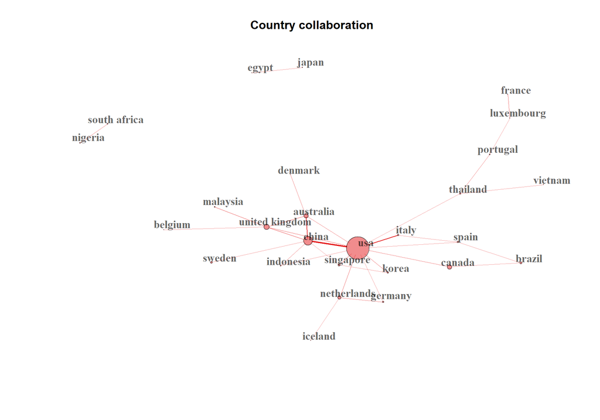

Figure 3: Countries Collaboration Map

```r
bib_concolab <- metaTagExtraction(bibds_wos, Field = "AU_CO", sep = ";")

bib_concolab_NetMatrix <- biblioNetwork(bib_concolab, analysis = "collaboration",
                                       network = "countries", sep = ";")

bib_concolab_Plot <- networkPlot(bib_concolab_NetMatrix,
                                 n = dim(bib_concolab_NetMatrix)[1],
                                 Title = "Country collaboration", type = "auto",
                                 size=10, size.cex=T, edgesize = 2, labelsize=1.1,
                                 edges.min = 2, remove.isolates = T, community.repulsion = 0,
                                 cluster = "none")
```

## 4.4 Institution

The publications in this field were from 1042 institutions. The top 10 productive institutions were shown in Table 2. The collaboration network between the institution was shown in Figure 4.

```r
bibres_insttable %>%
  rename("Number of Publications" = "Np",
         "Instituion Name" = "InstitutionAffiliation") %>%
  mutate(`Instituion Name` = stringr::str_to_title(`Instituion Name`)) %>%
  filter(`Number of Publications` >= 15) %>%
  kable() %>% kable_classic(full_width = F)
```

Table 2: Most Productive Institution

| Rank | Instituion Name | Number of Publications |
| --- | --- | --- |
| 1 | Univ Toronto | 65 |
| 2 | Univ Florida | 60 |
| 3 | Univ Alabama Birmingham | 49 |
| 4 | Natl Univ Singapore | 38 |
| 5 | Univ Texas Hlth Sci Ctr Houston | 36 |
| 6 | Univ Cincinnati | 34 |
| 7 | Chinese Univ Hong Kong | 31 |
| 8 | Maastricht Univ | 26 |
| 9 | Univ Roma Tor Vergata | 26 |
| 10 | Zhengzhou Univ | 26 |
| 11 | Northwestern Univ | 25 |
| 12 | Indiana Univ | 24 |
| 13 | Univ Toledo | 23 |
| 14 | Emory Univ | 19 |
| 15 | Univ Leeds | 19 |
| 16 | Vrije Univ Amsterdam | 19 |
| 17 | Univ Calgary | 18 |
| 18 | Univ Groningen | 17 |
| 19 | China Med Univ | 16 |
| 20 | Mahidol Univ | 16 |
| 21 | Univ Porto | 16 |
| 22 | Univ Texas Med Branch | 16 |
| 23 | Chang Gung Univ | 15 |
| 24 | Hong Kong Polytech Univ | 15 |
| 25 | Karolinska Inst | 15 |
| 26 | Kings Coll London | 15 |
| 27 | No Arizona Univ | 15 |
| 28 | Tianjin Med Univ | 15 |
| 29 | Univ Alabama | 15 |
| 30 | Univ N Carolina | 15 |
| 31 | Univ S Florida | 15 |

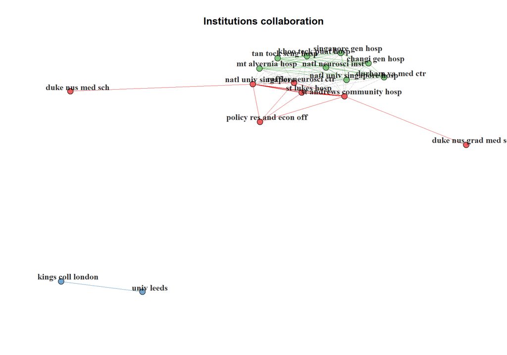

Figure 4: Institution Collaboration Map

```r
bib_educolab_NetMatrix <- biblioNetwork(bibds_wos, analysis = "collaboration",
                                       network = "universities", sep = ";")

bib_educolab_Plot <- networkPlot(bib_educolab_NetMatrix, n = 25,
                                 cluster = "optimal", type = "auto",
                                 size.cex = F, size = 3, remove.multiple = F,
                                 labelsize=1, alpha = .7, edgesize = 1,
                                 edges.min = 5, remove.isolates = T,
                                 community.repulsion = 0,
                                 Title = "Institutions collaboration")
```

## 4.5 Journals

A total of 260 journals have published articles in this field. Most of the journals only produced one article (63.8%). Based on Bradford’s Law, there were 12 journal in Zone 1, as the listed in Table 4.

Based on Bradford’s Law, Zone 1, which represent a core of a few journals, listed 12 most productive journal, with total of 224 articles published, correponding to 33% of total publications.

<sup>2</sup> manual

<sup>3</sup> manual

<sup>4</sup> manual

<sup>5</sup> manual

<sup>6</sup> manual

<sup>7</sup> manual

In the Zone 1, the journal was in stroke related field, rehabilitation related field, nursing related field, and general medical journals.

```r
bib_bradfordtable %>%
  select(-percent) %>%
  rename("No of Source (Journal)" = "nSO",
       "Total Article" = "nArt",
       "Source Rank" = "RankRange")%>%
  kable() %>%
  kable_classic(full_width = F)
```

Table 3: No of Journals and Articles by Zone of Bradford’s Law

| Zone | No of Source (Journal) | Total Article | Source Rank |
| --- | --- | --- | --- |
| Zone 1 | 12 | 224 | 1-12 |
| Zone 2 | 54 | 232 | 13-66 |
| Zone 3 | 194 | 222 | 67-260 |

```r
bib_bradford$table %>%
  filter(Zone == "Zone 1") %>%
  tibble() %>%
  mutate(SO = stringr::str_to_title(SO)) %>%
  rename("Journal Name" = "SO") %>%
  kable() %>%
  kable_classic(full_width = F)
```

Table 4: Journals in Zone 1 of Bradford’s Law

| Journal Name | Rank | Freq | cumFreq | Zone |
| --- | --- | --- | --- | --- |
| Topics In Stroke Rehabilitation | 1 | 40 | 40 | Zone 1 |
| Stroke | 2 | 29 | 69 | Zone 1 |
| Rehabilitation Nursing | 3 | 21 | 90 | Zone 1 |
| Journal Of Neuroscience Nursing | 4 | 20 | 110 | Zone 1 |
| Journal Of Clinical Nursing | 5 | 18 | 128 | Zone 1 |
| Journal Of Advanced Nursing | 6 | 17 | 145 | Zone 1 |
| Disability And Rehabilitation | 7 | 16 | 161 | Zone 1 |
| Rehabilitation Psychology | 8 | 15 | 176 | Zone 1 |
| Bmj Open | 9 | 14 | 190 | Zone 1 |
| Clinical Rehabilitation | 10 | 13 | 203 | Zone 1 |
| Archives Of Physical Medicine And Rehabilitation | 11 | 11 | 214 | Zone 1 |
| Scandinavian Journal Of Caring Sciences | 12 | 10 | 224 | Zone 1 |

```r
## label: tbl-top15journal
## tbl-cap: "Most Productive Journal"

# bibres_sourcetable %>%
#   rename("Number of Publications" = "Np",
#          "Source (Journal)" = "SourceJournal") %>%
#   mutate(`Source (Journal)` = stringr::str_to_title(`Source (Journal)`)) %>%
#   head(n = 15) %>%
#   kable() %>% kable_classic(full_width = F)
```

Journal co-citation analysis as shown in Figure 5

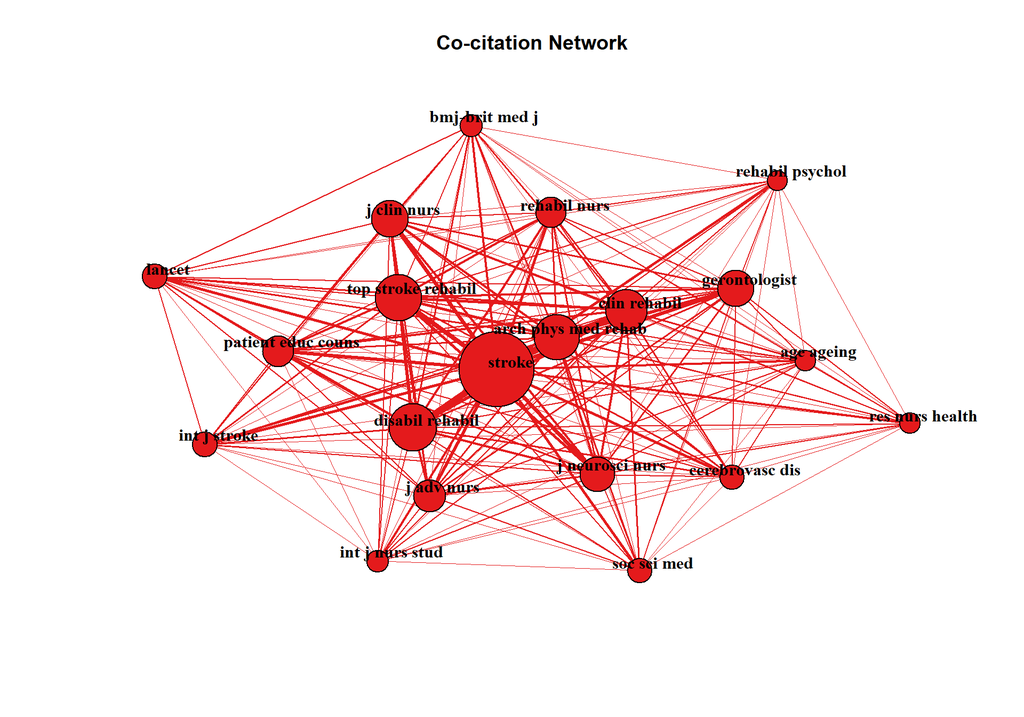

Figure 5: Journal Co-citation Analysis

```r
bib_CRSO <- metaTagExtraction(bibds_wos, Field = "CR_SO", sep = ";")
bib_CRSO_NetMatrix <- biblioNetwork(bib_CRSO, analysis = "co-citation",
                                    network = "sources", sep = ";")
bib_CRSO_Plot <- networkPlot(bib_CRSO_NetMatrix, n = 20,
                             Title = "Co-citation Network", type = "auto",
                             size.cex = T, size = 20, remove.multiple = F,
                             labelsize = 1, edgesize = 5, edges.min = 5, alpha = 1)
```

## 4.6 Authors

As shown in Figure 7, there was active co-operation relationships among the top productive reseach.

**Note**

find what most Bakas T papers about (among the articles)

```r
bibres_autable %>%
  rename("Number of Publications" = "Np") %>%
  mutate(Author = stringr::str_to_title(Author)) %>%
  head(n = 10) %>%
  kable() %>% kable_classic(full_width = F)
```

Table 5: Most Productive Authors

| Rank | Author | Number of Publications |
| --- | --- | --- |
| 1 | Bakas T | 21 |
| 2 | Grant Js | 15 |
| 3 | Lutz Bj | 13 |
| 4 | Roth Dl | 12 |
| 5 | Vellone E | 12 |
| 6 | Haley We | 11 |
| 7 | Koh Gch | 11 |
| 8 | Pucciarelli G | 11 |
| 9 | Alvaro R | 10 |
| 10 | Cameron Ji | 10 |

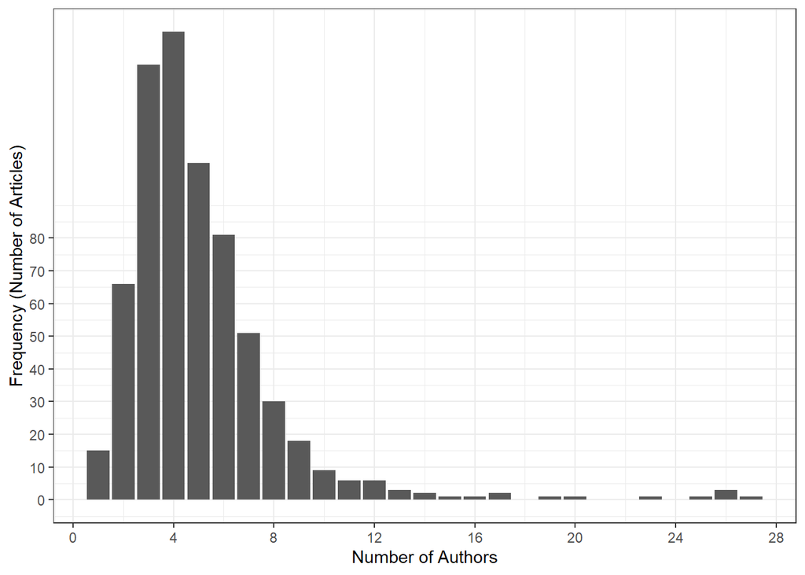

Figure 6: Number of authors per articles

```r
bibds_noaufreq %>%
  ggplot(aes(no_auth, freq)) +
  geom_bar(stat = "identity") +
  labs(x = "Number of Authors", y = "Frequency (Number of Articles)") +
  scale_x_continuous(breaks = seq(0,30,4)) +
  scale_y_continuous(breaks = seq(0,80,10)) +
  theme_bw()
```

All articles were subjected to a author coupling analysis to produce the network map, as shown in Figure 7. The connection between two nodes indicates that the articles have a common references, and the weighting reflect the coupling strength of the two nodes

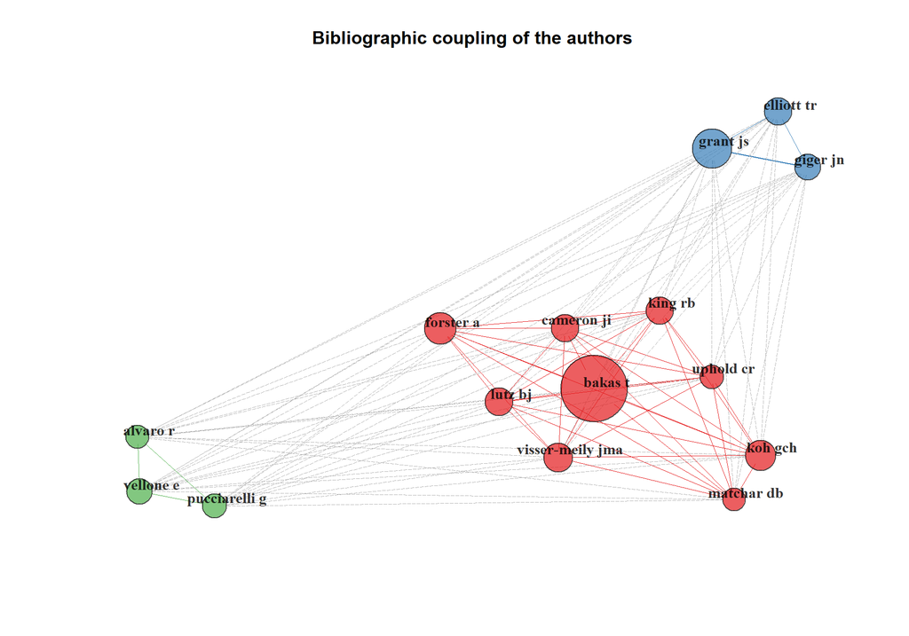

Figure 7: Author Coupling Analysis

```r
bib_AuCoupling_NetMatrix <- biblioNetwork(bibds_wos, analysis = "coupling",
                                          network = "authors", sep = ";")

bib_AuCoupling_Plot <- networkPlot(bib_AuCoupling_NetMatrix, n = 15,
                                   cluster = "optimal", type = "auto",
                                   size.cex = T, size = 20, remove.multiple = F,
                                   Title = "Bibliographic coupling of the authors",
                                   alpha = .7)
```

# 5 Articles and References

The top 10 most cited articles as shown in Table 6

```r
tibble(Title = bibds_wos$TI,
       Author = bibds_wos$AU,
       DOI = bibds_wos$DI,
       Citations = bibds_wos$TC) %>%
  mutate(across(.cols = c(Title, Author),
                .fns = str_to_title)) %>%
  arrange(desc(Citations)) %>%
  head(n=10) %>%
  kable() %>% kable_classic()
```

Table 6: Top 10 Most Cited Articles on Stroke Caregiver Burden

| Title | Author | DOI | Citations |
| --- | --- | --- | --- |
| Determinants Of Caregiving Burden And Quality Of Life In Caregivers Of Stroke Patients | Mccullagh E;Brigstocke G;Donaldson N;Kalra L | 10.1161/01.STR.0000181755.23914.53 | 277 |
| Determinants Of Quality Of Life In Stroke Survivors And Their Informal Caregivers | Jonsson Ac;Lindgren I;Hallstrom B;Norrving A | 10.1161/01.STR.0000160873.32791.20 | 220 |
| Caregiver's Burden Of Patients 3 Years After Stroke Assessed By A Novel Caregiver Burden Scale | Elmstahl S;Malmberg B;Annerstedt L | 10.1016/S0003-9993(96)90164-1 | 209 |
| Telephone Intervention With Family Caregivers Of Stroke Survivors After Rehabilitation | Grant Js;Elliott Tr;Weaver M;Bartolucci Aa;Giger Jn | 10.1161/01.STR.0000020711.38824.E3 | 204 |
| A Systematic Review Of Caregiver Burden Following Stroke | Rigby H;Gubitz G;Phillips S | 10.1111/j.1747-4949.2009.00289.x | 192 |
| Top 10 Research Priorities Relating To Life After Stroke - Consensus From Stroke Survivors, Caregivers, And Health Professionals | Pollock A;St George B;Fenton M;Firkins L | 10.1111/j.1747-4949.2012.00942.x | 190 |
| Stroke Patients' Informal Caregivers - Patient, Caregiver, And Service Factors That Affect Caregiver Strain | Bugge C;Alexander H;Hagen S | 10.1161/01.STR.30.8.1517 | 183 |
| Caregiver Burden And Health-Related Quality Of Life Among Japanese Stroke Caregivers | Morimoto T;Schreiner As;Asano H | 10.1093/ageing/32.2.218 | 180 |
| A Comparison Of Caregivers For Elderly Stroke And Dementia Victims | Draper Bm;Poulos Cj;Cole Amd;Poulos Rg;Ehrlich F | 10.1111/j.1532-5415.1992.tb01986.x | 177 |
| ``Timing It Right'': A Conceptual Framework For Addressing The Support Needs Of Family Caregivers To Stroke Survivors From The Hospital To The Home | Cameron Ji;Gignac Mam | 10.1016/j.pec.2007.10.020 | 170 |

## 5.1 Keyword

**Note**

summarise on keyword co-occurence matrix plot

Top 10 of most relevance keywords were shown in Table 7.

Using `bibliometrix` package, it was possible to analyse the most commonly used keywords in citations, most relevant being stroke, caregiver, survivor, burden, quality of life, health, depression and care.

```r
cbind(Rank = 1:10,
      bibres_summary$MostRelKeywords) %>%
  kable() %>% kable_classic(full_width = F)
```

Table 7: Top 10 Most Relevance Keyword

| Rank | Author Keywords (DE) | Articles | Keywords-Plus (ID) | Articles |
| --- | --- | --- | --- | --- |
| 1 | STROKE | 453 | SURVIVORS | 181 |
| 2 | CAREGIVERS | 198 | BURDEN | 179 |
| 3 | CAREGIVER | 118 | QUALITY-OF-LIFE | 149 |
| 4 | DEPRESSION | 82 | FAMILY CAREGIVERS | 137 |
| 5 | QUALITY OF LIFE | 73 | CARE | 136 |
| 6 | REHABILITATION | 70 | HEALTH | 132 |
| 7 | BURDEN | 44 | IMPACT | 114 |
| 8 | FAMILY CAREGIVERS | 44 | REHABILITATION | 88 |
| 9 | CAREGIVER BURDEN | 38 | DEPRESSION | 75 |
| 10 | ANXIETY | 30 | SPOUSES | 75 |

The keyword co-occurrence can be plotted as shown in Figure 8

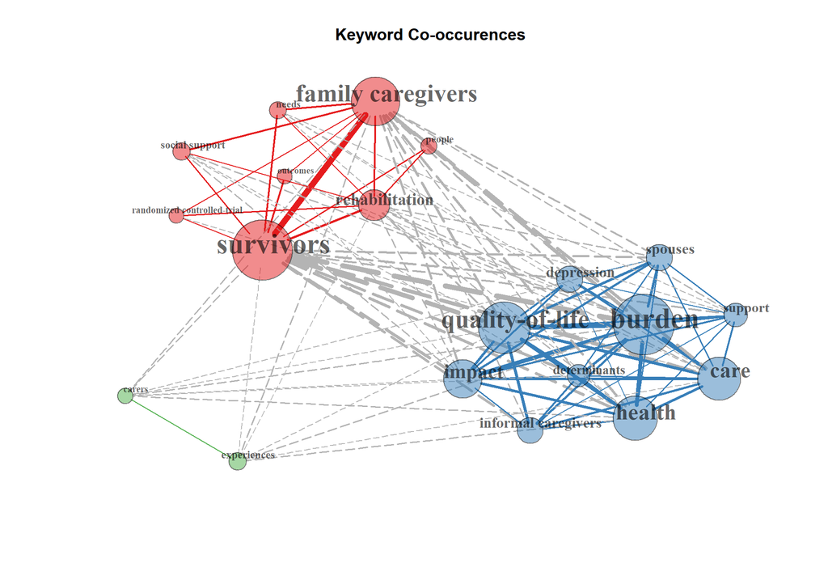

Figure 8: Keyword Co-occurences

```r
bib_kwco_NetMatrix <- biblioNetwork(bibds_wos, analysis = "co-occurrences",
                                     network = "keywords", sep = ";")

bib_kwco_Plot <- networkPlot(bib_kwco_NetMatrix, normalize = "association",
                             n = 20, Title = "Keyword Co-occurences",
                             cluster = "optimal", type = "fruchterman",
                             size.cex = T, size = 20,  remove.multiple = F,
                             edgesize = 7, labelsize = 3, label.cex = T,
                             label.n = 20, edges.min = 10)
```

Author keyword Trend

[figure not shown]

```r
bib_themeevolution_de <- fieldByYear(bibds_wos, field = "DE",
                                     timespan = c(2013,2022), min.freq = 20,
                                     n.items = 5)
```

Thematic Map

[figure not shown]

Figure 9: Thematic Map

```r
bib_thememap <- thematicMap(bibds_wos, field = "DE", n = 500, minfreq = 10,
                            stemming = F, size = .5, n.labels = 5, repel = T)

plot(bib_thememap$map)
```

# 6 Discussion

Demographic ageing is a worldwide process and is associated with an increased prevalence of stroke disease. It is inevitable that family caregivers and caregiver-related problems will increase, because most people with stroke live at home. The *world stroke report* states that the number of people with stroke in need of care is rapidly increasing in developing countries, and our studies show that the studies had fair share of both developed countries and developing countries. National policies and support stroke may play an important role in this phenomenon. For example, US declare stroke a national health priotiry, and was also lunch in other countries. China, the second most productive, indicating that China also make important contribution to this field[^8].

<sup>8</sup> find systematic review on stroke caregiver burden in China

**Note**

UK 2007 National Stroke Strategy

Further analysis show that the most closely cooperating institution were located in the same country and that cooperation among countries was not very common. the variation in health care systems, culture, family structure and care arrangement across countries and regions can lead to different health problem and countermeasures for caregivers, which may be reasons for the lack of international cooperation in this type of research.

**Note**

variation among countries - health services - regarding stroke caregiver

**Note**

WOS: (TI=(stroke) AND TI=(caregiver) AND TI=(trial))

Other than “stroke”, “caregiver” and “burden”, the hotspot analysis show that other widely studied topics include “depression”, “quality of life” and “determinant”. Studies have shown that approximately *30-55%* of caregivers suffer form anxiety or depression symptoms, which may result in changes in their behaviour and reduced quality of care. Although the existing outcome measures predominately focus on the negative aspect of caregiving, the positive aspects of caring, such as self-efficacy, resilience, rewards meaning and spirituality, have been overlooked. The positive aspects of caring could aid in the development of relevant positive psychology interventions. based on the above caregiver health issues, several international agreements and conventions were drafted by the WHO and stroke disease international, and some countries also have policies protecting the rights of caregivers, and national strategies for carers. However, most countries still do not have long-term care services and support for family caregiver of stroke survivors, such as intervention for caregivers health issues.

Several interventional available for caregivers include psychoeducational interventions, supportive interventions, psychotherapy, interventions to improve care r competency and multicomponent intervention.

Additionally, our studies shows that studies are increasingly conducted via the telephone and internet. The use of internet based intervention seem to have great potential and represent a trend for future research.

English is the most widely used and the USA is the country that has contributed the most to research on the subject.

The most commonly used terms in the publication was survivors, burden, family caregivers and care.

The loss of independence in performing daily life activities that stroke brings about leads the informal caregiver of the stroke survivors to change routines, lifestyles and family dynamics, with negative consequences on their physical and mental health. THus the caregiver is oftern forced to abdon life projects, especially when witnessing the degradation of the cognitive capacity of the stroke survivors. The uninterrupted character that the role of caregiver forces in most situation, with an average of 15 hour of daily care provision, constitutes in itself a factor of overload and weariness.

Women are the most representative group of informal caregiver of stroke survovrs, presenting a greater burden due tot eh accumulation of different social roles; however, there are no difference regarding resilience in caregiver of older people being displayed by children or spouses and those who are already retired.

The informal caregivers recognize that the informaiton they have in order to provide care is, in most situations, insufficeint for quality care, with inadequate care planning and lack of tools to deal with changes generated by the stroke. Thus the relationship between the caregiver and the stroke survivors may generate a dynamic that drives conflicts and tension, directly affecting the person receiving care, the caregiver and family dynamics. On the other hand, the caregiver of the stroke survivors recognizes that being a caregiver of his relative strengthened the affective relationship.

Healthcare, in turn, should include assessment of physical, cognitive, affective, social, financial, environmental and spiritual component, with the purpose of establishing a tangible therapeutic plan and integrated multidisciplinary follow-up, maintaining functional capacity, social reintegration and maintenance, and promoting decrease in institutionalization.

From this perspective, stroke team emerge as the health professionals better positioned to fill in information gaps with caregivers, as well as collaborate in adpative strategies, through the analysis of the real needs of informal caregvers and can be seen as social educator with consequent improvement in the quality of life of this binomial. The preponderant role of transmission of knowledge and skill to the stroke survivors and the informal caregiver stnads out, with a view to a safe transition and adaptation to the new health condition, giving continuity with the care nitiated at hospital level, since health-disease transitions with less positive outcomes are generators of dependence. The transition processess are then seen as complex, demanding and implying a paradigm shift in the provision of care to the vulnerable person, requiring reconfiguration of the nurses’ role and multidisciplinary conjugation, encompassing all participants in the process, not forgetting the informal caregiver.

Nevertheless, it is crucial to take account that a large majority of stroke caregivers also have their own comitment. The overload to which these caregivers are subject when performing their role as informal caregiver, often concomitant with their profession, that result in abandonment of care and inevitable instituionalization.

Thus the paradigm of care focused on the stroke survivors encompases biological and psychosocial aspects with the aim of a global and integrative perspective with the purpose of fully satisfying human rights, focusing on self-determination, valuing individual characteristics, expectations and potentialities, and emphasizing the quality of the relationship in the provision of care.

The goal of holistic, individualized and quality care provided to stroke survivors, caregivers, contemplates room for a care partner, from the initial moments of diagnosis, involving multidisciplinary care, until evaluation, taking into account this multidisciplinary in the intervention plan, the rehab hcw seens as an asset in providing family memebrs with better trianing and information, with a view toward the best and most adapted therapeutic process.

## 6.1 limitation

- some publication may not have been analysed because they were not well catalogued or not published according to the inclusion criteria.

# 7 Conclusion

An overview of research on health interventions for stroke caregivers was presented, providing information related to the number of annual publications, countries, journals, institutions, authors and research trends. There is an uregent global unmet need for effective scalable interventions for caregiver of peopele with stroke, given the fast moving pace of this research area. We believe that the key to improve health of family caregivers of stroke survivors lies in unique combination of global solutions and local knowledge. International cooperation should be strengthened to solve this problem. Future research needs the generalisation of treatment effects in different countries and caregivers of stroke survivors need to be addressed. Furthermore, it is evident that RCT evidence is only a part of the current body of evidence; more attention to non-RCT evicence may substantitally help future trial designs, and a realist review could be undertaken to enhance our understanding of the complexity of the implementation and impacts of intervention.

In summary, we identify and analyzed the characteristic of the research on the health of and interventions for stroke survivors caregivers. The result may help guide researchers and funding agencies to the most important research areas in the field.

This bibliometric review regarding the stroke caregiver allowed us to conclude that there has been growing interest in this topic by the scientific community, which has been more pronounced in the last 5 years and is ususally assoicated with caregiver well-being, more specifically burden and quality of life.

in view of the expected increse in stroke survivors and dependence rates in the coming years, it is expeceted that there will be a growing need for a transition element capable of responding to the needs of an incresing stroke survivor and dependent population with a view to maintaining quality of life, with caregiver emerging as partner in care, and adherence to the therapeutic regime.

Due to the great relevance and growing interest in the topic, this represent a concept that still requires further research, particularly regarding the concept definiton and its role in today’s society as well as its impact on health-illness transition or continuity of care. It is also concluded that the issues related to stroke diseases are closely assoicated tith the concept of informal caregiver, which may be incorporated into future research.

# 8 Supplementary

## 8.1 Co-citation Network

### 8.1.1 References

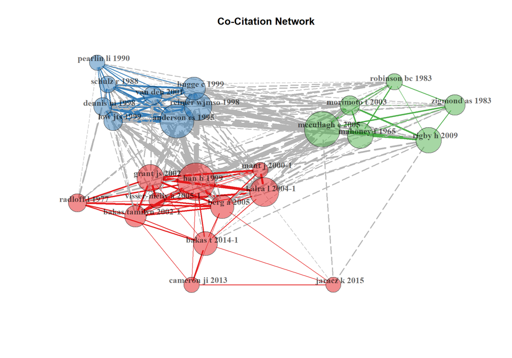

Figure 10: Article Co-citation Analysis

```r
bib_ArCo_NetMatrix <- biblioNetwork(bibds_wos, analysis = "co-citation",
                                    network = "references", sep = ";")

bib_ArCo_Plot <- networkPlot(bib_ArCo_NetMatrix, n = 25,
                             Title = "Co-Citation Network", type = "fruchterman",
                             size.cex = T,  size = 20, remove.multiple = F,
                             labelsize = 1, edgesize = 10, edges.min = 5)
```

## 8.2 Histiograph

Historical Direct Citation Network for 20 authors as shown in Figure 11

```r
bib_histResults <- histNetwork(bibds_wos, sep = ";")
bib_historio_plot <- histPlot(bib_histResults, n = 20, size = 5, labelsize = 4)
```

[figure not shown]

Figure 11: Historical Direct Citation Network

```r
bib_historio_plot$g
```

## 8.3 Co-word Analysis through Correspondence Analysis

[figure not shown]

[figure not shown]

[figure not shown]

[figure not shown]

```r
bib_CS_Plot <- conceptualStructure(bibds_wos, method = "MCA", field = "ID",
                                   minDegree = 15, clust = 5, stemming = F,
                                   labelsize = 15, documents = 20)
```

## 8.4 Other Author’s related Analysis

### 8.4.1 Author dominance ranking

```r
dominance(bibres, k = 10) %>%
  mutate(Author = stringr::str_to_title(Author)) %>%
  kable() %>%
  kable_classic(full_width = F)
```

Table 8: Top 10 Author Dominance

| Author | Dominance Factor | Tot Articles | Single-Authored | Multi-Authored | First-Authored | Rank by Articles | Rank by DF |
| --- | --- | --- | --- | --- | --- | --- | --- |
| Pierce Ll | 0.8888889 | 10 | 1 | 9 | 8 | 8 | 1 |
| Pucciarelli G | 0.8181818 | 11 | 0 | 11 | 9 | 6 | 2 |
| Grant Js | 0.8000000 | 15 | 0 | 15 | 12 | 2 | 3 |
| Cameron Ji | 0.6000000 | 10 | 0 | 10 | 6 | 8 | 4 |
| Bakas T | 0.5238095 | 21 | 0 | 21 | 11 | 1 | 5 |
| Forster A | 0.5000000 | 10 | 0 | 10 | 5 | 8 | 6 |
| Haley We | 0.3636364 | 11 | 0 | 11 | 4 | 6 | 7 |
| Lutz Bj | 0.3076923 | 13 | 0 | 13 | 4 | 3 | 8 |
| Roth Dl | 0.1666667 | 12 | 0 | 12 | 2 | 4 | 9 |
| Vellone E | 0.0833333 | 12 | 0 | 12 | 1 | 4 | 10 |

### 8.4.2 Author H-Index

```r
bib_authors <- gsub(","," ",names(bibres$Authors))

bib_hindex <- Hindex(bibds_wos, field = "author", elements = bib_authors,
                    sep = ";", years = 20)

bib_hindex$H %>%
  arrange(desc(h_index),desc(TC)) %>%
  mutate(Element = stringr::str_to_title(Element)) %>%
  head(n = 10) %>%
  kable(digits = 2) %>%
  kable_classic(full_width = F)
```

| Element | h_index | g_index | m_index | TC | NP | PY_start |
| --- | --- | --- | --- | --- | --- | --- |
| Grant Js | 10 | 12 | 0.48 | 639 | 12 | 2002 |
| Bakas T | 10 | 21 | 0.59 | 596 | 21 | 2006 |
| Forster A | 10 | 10 | 0.67 | 538 | 10 | 2008 |
| Lutz Bj | 10 | 11 | 0.62 | 481 | 11 | 2007 |
| Cameron Ji | 9 | 10 | 0.53 | 524 | 10 | 2006 |
| Roth Dl | 8 | 12 | 0.57 | 431 | 12 | 2009 |
| Elliott Tr | 7 | 7 | 0.33 | 450 | 7 | 2002 |
| Haley We | 7 | 11 | 0.50 | 415 | 11 | 2009 |
| Vellone E | 7 | 11 | 0.58 | 249 | 11 | 2011 |
| Pucciarelli G | 7 | 10 | 0.78 | 247 | 10 | 2014 |

## 8.5 Author Production over Time

[figure not shown]

```r
bib_topAUtime <- authorProdOverTime(bibds_wos, k = 30)
```

## References

Aria, Massimo, and Corrado Cuccurullo. 2017. “Bibliometrix : An R-tool for Comprehensive Science Mapping Analysis.” *Journal of Informetrics* 11 (4): 959–75. https://doi.org/10.1016/j.joi.2017.08.007.

R Core Team. 2022. “R: A Language and Environment for Statistical Computing.” Vienna, Austria: R Foundation for Statistical Computing.

RStudio Team. 2022. “RStudio: Integrated Development Environment for R.” Boston, MA: RStudio, PBC.

## Reuse

https://creativecommons.org/licenses/by/4.0/